# Social network analysis - Squid Game style - Episode 3 - Tug of War

Adapted from Pablo Barbera’s very helpful example:  
http://pablobarbera.com/big-data-upf/html/02a-networks-intro-visualization.html

## Installing required packages

```r
# to install the other packages, run the codes below
 #install.packages("igraph")
```

## Loading packages

```r
library("igraph")
```

## Tug of War

In the Tug of War game, Squid Game players get to choose their team mates. We want to use social network analysis to determine the interactions and relationships between players, which will then dictate how team mates are chosen.

## Importing network data

In this tutorial we will be using a small network that indicates interactions in the Squid Game series. Here, each node is a character and each edge indicates whether they appeared together in a scene of the series. Edges here are thus undirected and they also have weights attached, since they can appear in multiple scenes together.

The first step is to read the list of edges and nodes in this network:

```r
edges <- read.csv("squidgame-network-edges.csv")
head(edges)
```

|  | source | target | weight |
| --- | --- | --- | --- |
| 1 | Abdul Ali_P199 | Il-nam_P001 | 5 |
| 2 | Abdul Ali_P199 | P240 | 17 |
| 3 | Abdul Ali_P199 | Gi-hun_P456 | 1 |
| 4 | Abdul Ali_P199 | Gangster_P101 | 1 |
| 5 | Abdul Ali_P199 | Loud_woman_P212 | 1 |
| 6 | Abdul Ali_P199 | P077 | 1 |

```r
nodes <- read.csv("squidgame-network-nodes.csv")
head(nodes)
```

|  | name | id |
| --- | --- | --- |
| 1 | Gi-hun_P456 | 10 |
| 2 | Il-nam_P001 | 0 |
| 3 | Sae-byeok_P067 | 1 |
| 4 | Sang-woo_P218 | 13 |
| 5 | Abdul Ali_P199 | 7 |
| 6 | Doctor_P111 | 4 |

For example, we learn that Abdul Ali (player 199) and Il-nam (player 001) appeared in 5 scenes together.

Now, how do we create the igraph object? We can use the `graph_from_data_frame` function, which takes two arguments: `d`, the data frame with the edge list in the first two columns; and `vertices`, a data frame with node data with the node label in the first column. (Note that igraph calls the nodes `vertices`, but it’s exactly the same thing.)

```r
g <- graph_from_data_frame(d=edges, vertices=nodes, directed=FALSE)
g
```

```
## IGRAPH 5641aae UNW- 22 60 --
## + attr: name (v/c), id (v/n), weight (e/n)
## + edges from 5641aae (vertex names):
##  [1] Il-nam_P001   --Abdul Ali_P199  Abdul Ali_P199--P240
##  [3] Gi-hun_P456   --Abdul Ali_P199  Abdul Ali_P199--Gangster_P101
##  [5] Abdul Ali_P199--Loud_woman_P212 Abdul Ali_P199--P077
##  [7] Abdul Ali_P199--Doctor_P111     Doctor_P111   --Gangster_P101
##  [9] Doctor_P111   --Loud_woman_P212 Gi-hun_P456   --Doctor_P111
## [11] Gangster_P101 --Loud_woman_P212 Gi-hun_P456   --Il-nam_P001
## [13] P244          --P017            P240          --P017
## [15] Abdul Ali_P199--P017            P017          --P077
## + ... omitted several edges
```

What does it mean?  
- `U` means undirected  
- `N` means named graph  
- `W` means weighted graph  
- `22` is the number of nodes  
- `60` is the number of edges  
- `name (v/c)` means *name* is a node attribute and it’s a character  
- `weight (e/n)` means *weight* is an edge attribute and it’s numeric

This is how you access specific elements within the igraph object:

```r
V(g) # nodes
```

```
## + 22/22 vertices, named, from 5641aae:
##  [1] Gi-hun_P456     Il-nam_P001     Sae-byeok_P067  Sang-woo_P218
##  [5] Abdul Ali_P199  Doctor_P111     Gangster_P101   Loud_woman_P212
##  [9] P045            P240            P244            P017
## [13] P069            P070            P278            P276
## [17] P102            P372            P385            P077
## [21] P124            P291
```

```r
V(g)$name # names of each node
```

```
##  [1] "Gi-hun_P456"     "Il-nam_P001"     "Sae-byeok_P067"  "Sang-woo_P218"
##  [5] "Abdul Ali_P199"  "Doctor_P111"     "Gangster_P101"   "Loud_woman_P212"
##  [9] "P045"            "P240"            "P244"            "P017"
## [13] "P069"            "P070"            "P278"            "P276"
## [17] "P102"            "P372"            "P385"            "P077"
## [21] "P124"            "P291"
```

```r
vertex_attr(g) # all attributes of the nodes
```

```
## $name
##  [1] "Gi-hun_P456"     "Il-nam_P001"     "Sae-byeok_P067"  "Sang-woo_P218"
##  [5] "Abdul Ali_P199"  "Doctor_P111"     "Gangster_P101"   "Loud_woman_P212"
##  [9] "P045"            "P240"            "P244"            "P017"
## [13] "P069"            "P070"            "P278"            "P276"
## [17] "P102"            "P372"            "P385"            "P077"
## [21] "P124"            "P291"
##
## $id
##  [1] 10  0  1 13  7  4 11 12  2  3  5  6  8  9 14 15 16 17 18 19 20 21
```

```r
E(g) # edges
```

```
## + 60/60 edges from 5641aae (vertex names):
##  [1] Il-nam_P001   --Abdul Ali_P199  Abdul Ali_P199--P240
##  [3] Gi-hun_P456   --Abdul Ali_P199  Abdul Ali_P199--Gangster_P101
##  [5] Abdul Ali_P199--Loud_woman_P212 Abdul Ali_P199--P077
##  [7] Abdul Ali_P199--Doctor_P111     Doctor_P111   --Gangster_P101
##  [9] Doctor_P111   --Loud_woman_P212 Gi-hun_P456   --Doctor_P111
## [11] Gangster_P101 --Loud_woman_P212 Gi-hun_P456   --Il-nam_P001
## [13] P244          --P017            P240          --P017
## [15] Abdul Ali_P199--P017            P017          --P077
## [17] P045          --P017            P017          --P385
## [19] P017          --P372            Il-nam_P001   --P045
## + ... omitted several edges
```

```r
E(g)$weight # weights for each edge
```

```
##  [1]  5 17  1  1  1  1  1  1  7  1  2  6  2  4  1  3  1  2  1 17  5 18  2  6  6
## [26]  6  1  3  3  2  1  3  1  1  1  1  1 13  3 19  2  3  1  2  1  1  1  1  3  7
## [51] 16 19 11  1  1  5  9 26  1 13
```

```r
edge_attr(g) # all attributes of the edges
```

```
## $weight
##  [1]  5 17  1  1  1  1  1  1  7  1  2  6  2  4  1  3  1  2  1 17  5 18  2  6  6
## [26]  6  1  3  3  2  1  3  1  1  1  1  1 13  3 19  2  3  1  2  1  1  1  1  3  7
## [51] 16 19 11  1  1  5  9 26  1 13
```

```r
g[] # adjacency matrix
```

```
## 22 x 22 sparse Matrix of class "dgCMatrix"
```

```
##    [[ suppressing 22 column names 'Gi-hun_P456', 'Il-nam_P001', 'Sae-byeok_P067' ... ]]
```

```
##
## Gi-hun_P456      .  6  7  9  1 1 . .  6 19 . . . . . . . . . . . .
## Il-nam_P001      6  .  3  5  5 . . . 17 13 . . . . . . 1 . . . . .
## Sae-byeok_P067   7  3  . 19 11 1 . .  5 16 . . . . . . 1 . . . . .
## Sang-woo_P218    9  5 19  . 13 . . .  6 26 . . . . 1 1 . . . . . .
## Abdul Ali_P199   1  5 11 13  . 1 1 1  6 17 . 1 1 . . . . . . 1 . .
## Doctor_P111      1  .  1  .  1 . 1 7  .  . . . . . . . . . . . . .
## Gangster_P101    .  .  .  .  1 1 . 2  .  . . . . . . . . . . . . .
## Loud_woman_P212  .  .  .  .  1 7 2 .  .  . . . . . . . . . . . . .
## P045             6 17  5  6  6 . . .  . 18 . 1 2 2 . . . . . 1 . .
## P240            19 13 16 26 17 . . . 18  . 2 4 3 3 . . 1 1 2 3 1 .
## P244             .  .  .  .  . . . .  .  2 . 2 . . . . . . . . . .
## P017             .  .  .  .  1 . . .  1  4 2 . . . . . . 1 2 3 . .
## P069             .  .  .  .  1 . . .  2  3 . . . 3 . . . . . . . .
## P070             .  .  .  .  . . . .  2  3 . . 3 . . . . . . . . .
## P278             .  .  .  1  . . . .  .  . . . . . . . . . . . . .
## P276             .  .  .  1  . . . .  .  . . . . . . . . . . . . .
## P102             .  1  1  .  . . . .  .  1 . . . . . . . 1 1 . . .
## P372             .  .  .  .  . . . .  .  1 . 1 . . . . 1 . 1 1 . .
## P385             .  .  .  .  . . . .  .  2 . 2 . . . . 1 1 . 3 . .
## P077             .  .  .  .  1 . . .  1  3 . 3 . . . . . 1 3 . 1 .
## P124             .  .  .  .  . . . .  .  1 . . . . . . . . . 1 . .
## P291             .  .  .  .  . . . .  .  . . . . . . . . . . . . .
```

```r
g[1,] # first row of adjacency matrix
```

```
##     Gi-hun_P456     Il-nam_P001  Sae-byeok_P067   Sang-woo_P218  Abdul Ali_P199
##               0               6               7               9               1
##     Doctor_P111   Gangster_P101 Loud_woman_P212            P045            P240
##               1               0               0               6              19
##            P244            P017            P069            P070            P278
##               0               0               0               0               0
##            P276            P102            P372            P385            P077
##               0               0               0               0               0
##            P124            P291
##               0               0
```

## Network visualization

How can we visualize this network? The `plot()` function works out of the box, but the default options are often not ideal:

[figure not shown]

```r
par(mar=c(0,0,0,0))
plot(g)
```

Let’s see how we can improve this figure. To see all the available plotting options, you can check `?igraph.plotting`. Let’s start by fixing some of these.

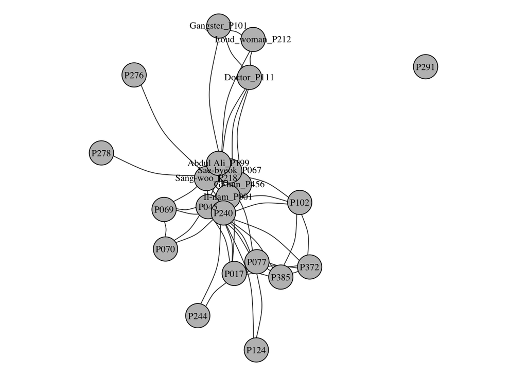

```r
par(mar=c(0,0,0,0))
plot(g,
     vertex.color = "grey", # change color of nodes
     vertex.label.color = "black", # change color of labels
     vertex.label.cex = .75, # change size of labels to 75% of original size
     edge.curved=.25, # add a 25% curve to the edges
     edge.color="grey20") # change edge color to grey
```

Now imagine that we want to modify some of these plotting attributes so that they are function of network properties. For example, a common adjustment is to change the size of the nodes and node labels so that they match their `importance` (we’ll come back to how to measure that later). Here, `strength` will correspond to the number of scenes they appear in. And we’re only going to show the labels of character that appear in 10 or more scenes.

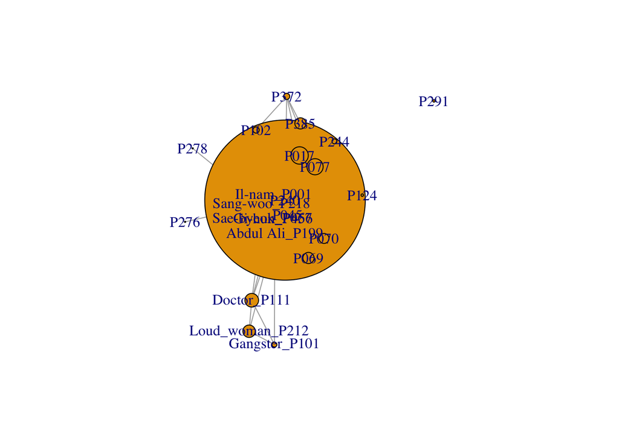

```r
V(g)$size <- strength(g)
par(mar=c(0,0,0,0)); plot(g)
```

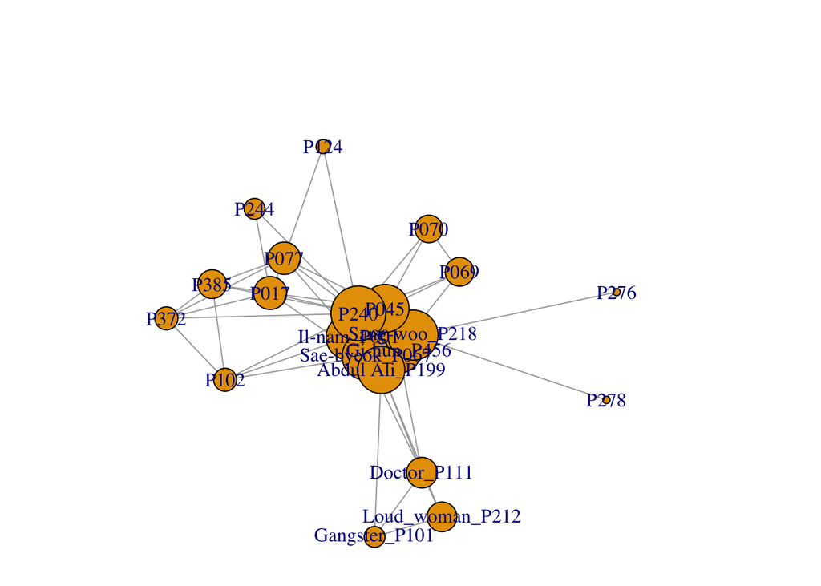

```r
# taking the log to improve it
V(g)$size <- log(strength(g)) * 4 + 3
par(mar=c(0,0,0,0)); plot(g)
```

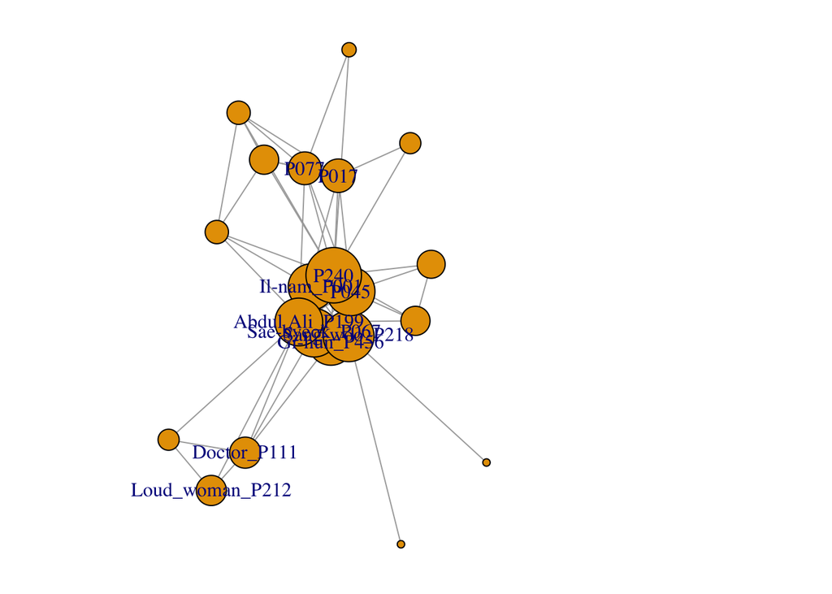

```r
V(g)$label <- ifelse( strength(g)>=10, V(g)$name, NA )
par(mar=c(0,0,0,0)); plot(g)
```

We can also change the colors of each node based on what side they’re in (gangster, protagonist/main cast and other).

```r
# create vectors with characters in each side
gangster <- c("Doctor_P111","Gangster_P101","Loud_woman_P212")
main_cast <- c("Gi-hun_P456","Il-nam_P001","Sae-byeok_P067","Sang-woo_P218","Abdul Ali_P199")
other <- c("P045","P240","P244","P017","P069","P070","P278","P276","P102","P372","P385","P077","P124","P291")
# node we'll create a new color variable as a node property
V(g)$color <- NA
V(g)$color[V(g)$name %in% gangster] <- "red"
V(g)$color[V(g)$name %in% main_cast] <- "gold"
V(g)$color[V(g)$name %in% other] <- "green"
vertex_attr(g)
```

```
## $name
##  [1] "Gi-hun_P456"     "Il-nam_P001"     "Sae-byeok_P067"  "Sang-woo_P218"
##  [5] "Abdul Ali_P199"  "Doctor_P111"     "Gangster_P101"   "Loud_woman_P212"
##  [9] "P045"            "P240"            "P244"            "P017"
## [13] "P069"            "P070"            "P278"            "P276"
## [17] "P102"            "P372"            "P385"            "P077"
## [21] "P124"            "P291"
##
## $id
##  [1] 10  0  1 13  7  4 11 12  2  3  5  6  8  9 14 15 16 17 18 19 20 21
##
## $size
##  [1] 18.567281 18.648092 19.572539 20.528107 19.310150 12.591581  8.545177
##  [8] 12.210340 19.635532 22.439250  8.545177 13.556229 11.788898 11.317766
## [15]  3.000000  3.000000  9.437752  9.437752 11.788898 13.259797  5.772589
## [22]      -Inf
##
## $label
##  [1] "Gi-hun_P456"     "Il-nam_P001"     "Sae-byeok_P067"  "Sang-woo_P218"
##  [5] "Abdul Ali_P199"  "Doctor_P111"     NA                "Loud_woman_P212"
##  [9] "P045"            "P240"            NA                "P017"
## [13] NA                NA                NA                NA
## [17] NA                NA                NA                "P077"
## [21] NA                NA
##
## $color
##  [1] "gold"  "gold"  "gold"  "gold"  "gold"  "red"   "red"   "red"   "green"
## [10] "green" "green" "green" "green" "green" "green" "green" "green" "green"
## [19] "green" "green" "green" "green"
```

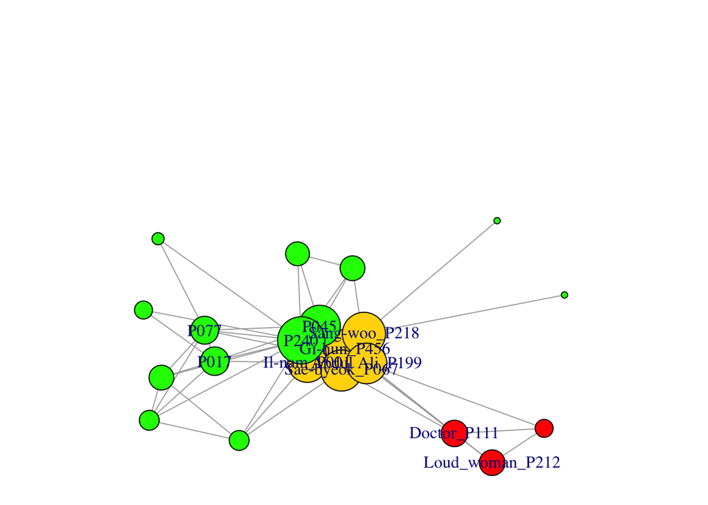

```r
par(mar=c(0,0,0,0)); plot(g)
```

If we want to indicate what the colors correspond to, we can add a legend.

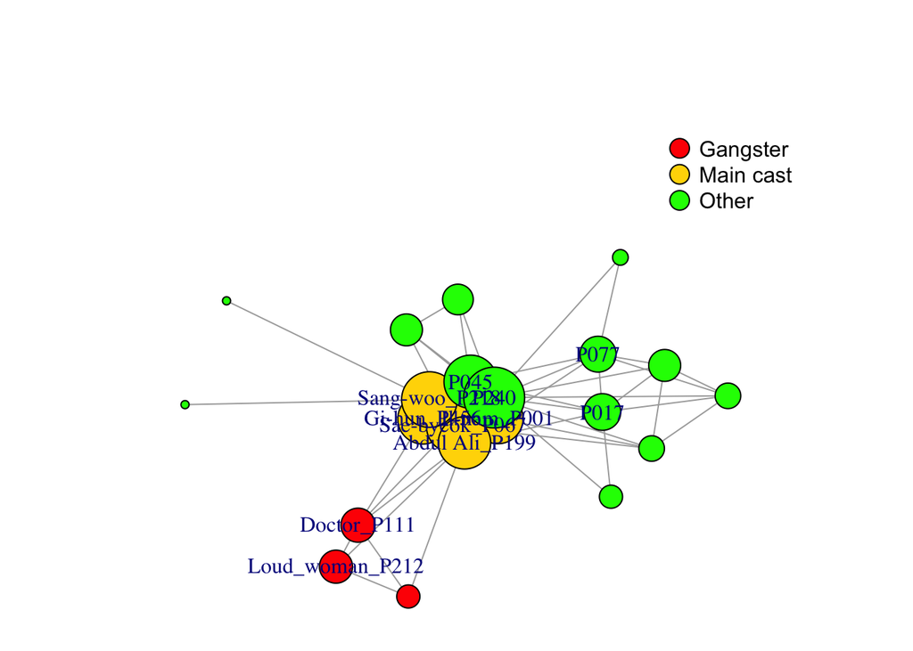

```r
par(mar=c(0,0,0,0)); plot(g)
legend(x=.75, y=.75, legend=c("Gangster", "Main cast", "Other"),
       pch=21, pt.bg=c("red", "gold", "green"), pt.cex=2, bty="n")
```

Edge properties can also be modified. For example, here the width of each edge is a function of the log number of scenes those two characters appear together.

```r
E(g)$width <- log(E(g)$weight) + 1
edge_attr(g)
```

```
## $weight
##  [1]  5 17  1  1  1  1  1  1  7  1  2  6  2  4  1  3  1  2  1 17  5 18  2  6  6
## [26]  6  1  3  3  2  1  3  1  1  1  1  1 13  3 19  2  3  1  2  1  1  1  1  3  7
## [51] 16 19 11  1  1  5  9 26  1 13
##
## $width
##  [1] 2.609438 3.833213 1.000000 1.000000 1.000000 1.000000 1.000000 1.000000
##  [9] 2.945910 1.000000 1.693147 2.791759 1.693147 2.386294 1.000000 2.098612
## [17] 1.000000 1.693147 1.000000 3.833213 2.609438 3.890372 1.693147 2.791759
## [25] 2.791759 2.791759 1.000000 2.098612 2.098612 1.693147 1.000000 2.098612
## [33] 1.000000 1.000000 1.000000 1.000000 1.000000 3.564949 2.098612 3.944439
## [41] 1.693147 2.098612 1.000000 1.693147 1.000000 1.000000 1.000000 1.000000
## [49] 2.098612 2.945910 3.772589 3.944439 3.397895 1.000000 1.000000 2.609438
## [57] 3.197225 4.258097 1.000000 3.564949
```

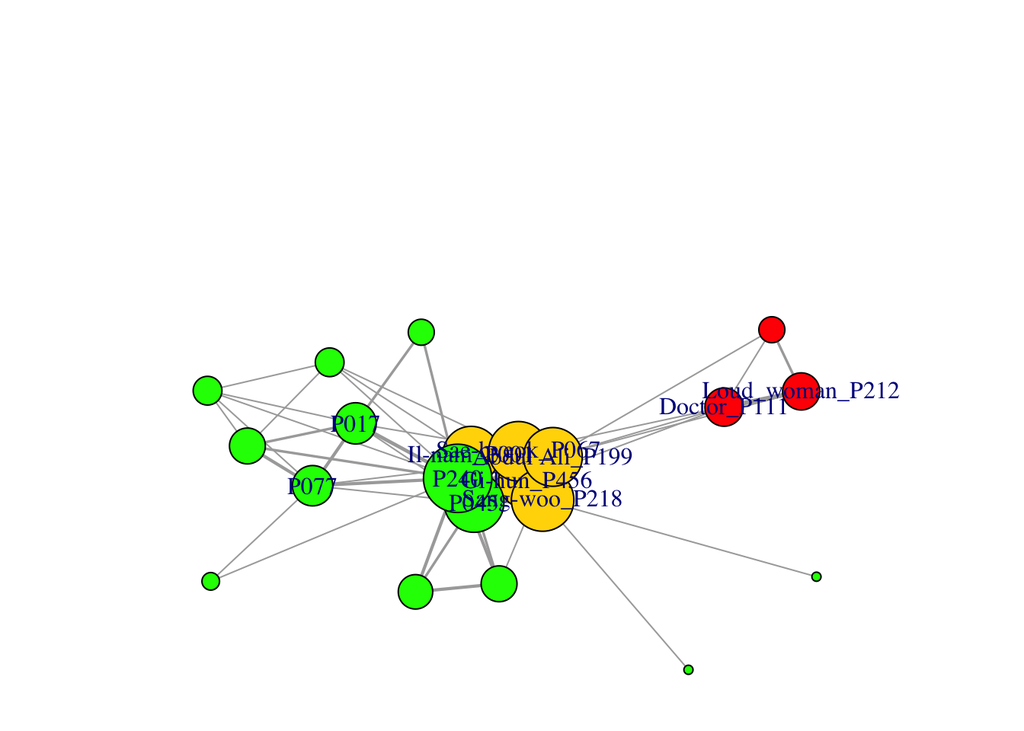

```r
par(mar=c(0,0,0,0)); plot(g)
```

Up to now, everytime we run the `plot` function, the nodes appear to be in a different location. Why? Because it’s running a probabilistic function trying to locate them in the optimal way possible.

However, we can also specify the **layout** for the plot; that is, the (x,y) coordinates where each node will be placed. `igraph` has a few different layouts built-in, that will use different algorithms to find an `optimal` distribution of nodes. The following code illustrates some of these:

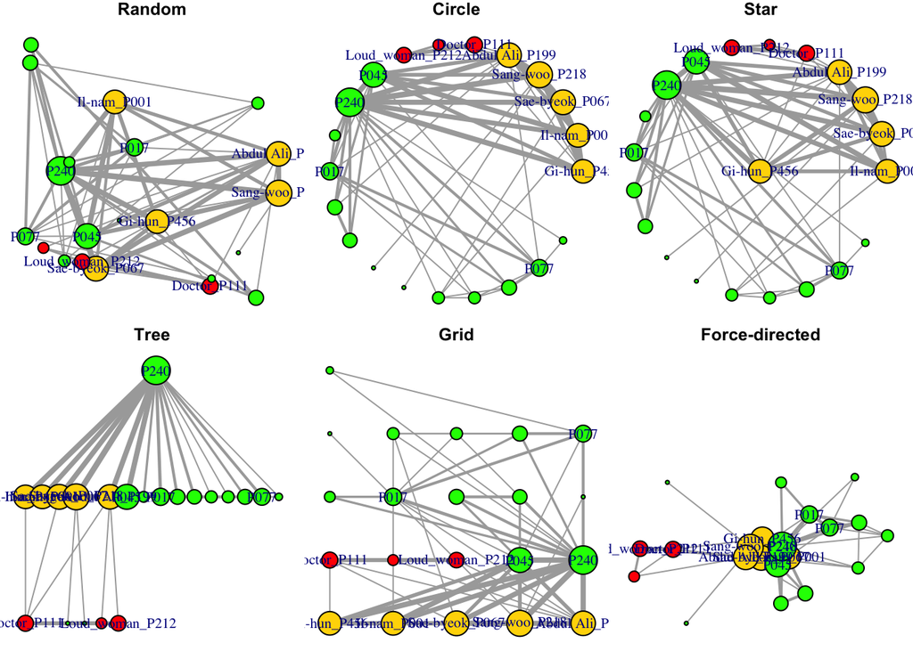

```r
par(mfrow=c(2, 3), mar=c(0,0,1,0))
plot(g, layout=layout_randomly, main="Random")
plot(g, layout=layout_in_circle, main="Circle")
plot(g, layout=layout_as_star, main="Star")
plot(g, layout=layout_as_tree, main="Tree")
plot(g, layout=layout_on_grid, main="Grid")
plot(g, layout=layout_with_fr, main="Force-directed")
```

Note that each of these is actually just a matrix of (x,y) locations for each node.

```r
l <- layout_randomly(g)
str(l)
```

```
##  num [1:22, 1:2] -0.472 0.651 0.808 0.632 -0.13 ...
```

The most popular layouts are [force-directed](https://en.wikipedia.org/wiki/Force-directed_graph_drawing). These algorithms, such as Fruchterman-Reingold, try to position the nodes so that the edges have similar length and there are as few crossing edges as possible. The idea is to generate “clean” layouts, where nodes that are closer to each other share more connections in common that those that are located further apart. Note that this is a non-deterministic algorithm: choosing a different seed will generate different layouts.

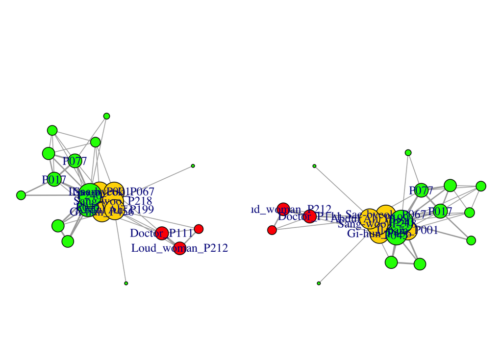

```r
par(mfrow=c(1,2))
set.seed(777)
fr <- layout_with_fr(g, niter=1000)
par(mar=c(0,0,0,0)); plot(g, layout=fr)
set.seed(666)
fr <- layout_with_fr(g, niter=1000)
par(mar=c(0,0,0,0)); plot(g, layout=fr)
```